# Computer Vision Project

## Author: Abhinav Roy

### Date - 13/03/2023

```python
# import the important packages
import pandas as pd #library used for data manipulation and analysis
import numpy as np # library used for working with arrays.
import matplotlib.pyplot as plt # library for plots and visualisations
import seaborn as sns # library for visualisations
import plotly.express as px # library for visualisations
%matplotlib inline
import missingno as msno
import random

import scipy.stats as stats # this library contains a large number of probability distributions as well as a growing library of statistical functions.
from scipy.stats import *
from scipy.spatial.distance import cdist
from math import *
'''
!pip install pandasql
import pandasql as psql
from pandasql import sqldf
'''
import string
alphabet = string.ascii_letters+string.punctuation

from mpl_toolkits.mplot3d import Axes3D

from patsy import dmatrices
from statsmodels.stats.outliers_influence import variance_inflation_factor

import time
from datetime import datetime

from collections import Counter

import pickle

import warnings # ignore warnings
warnings.filterwarnings("ignore")
```

```python
# import machine learning algorithms
from sklearn.preprocessing import LabelEncoder, MinMaxScaler, StandardScaler
from sklearn.model_selection import train_test_split
from sklearn import metrics
#from sklearn.metrics import classification_report, confusion_matrix , accuracy_score
from sklearn.metrics import *
from sklearn import model_selection
#from sklearn.model_selection import cross_val_score, cross_validate, GridSearchCV, learning_curve
from sklearn.model_selection import *
from sklearn.linear_model import LinearRegression, LogisticRegression, Ridge, Lasso
from sklearn.naive_bayes import GaussianNB
from sklearn.neighbors import KNeighborsClassifier
from sklearn.svm import SVC
from sklearn.tree import DecisionTreeRegressor, DecisionTreeClassifier
#from sklearn.ensemble import BaggingRegressor, RandomForestRegressor, GradientBoostingRegressor, RandomForestClassifier
from sklearn.ensemble import *
#!pip install catboost
#from catboost import CatBoostRegressor
from lightgbm import LGBMRegressor
from xgboost import XGBClassifier, XGBRegressor
from sklearn.cluster import KMeans
from sklearn.decomposition import PCA

# install and import SMOTE module from imblearn library
#!pip install imblearn
from imblearn.over_sampling import RandomOverSampler, SMOTENC, SMOTE

#!pip install eli5
#import eli5
```

```python
# import Neural Network libraries
import tensorflow
print(tensorflow.__version__)

from keras.utils.np_utils import to_categorical
from keras.utils.np_utils import *
from keras.models import Sequential # Forward prop
#from keras.layers import Dense, Activation, Dropout, BatchNormalization, LayerNormalization, SwitchableNormalization, LeakyReLU, ELU, Flatten
#from keras.layers import Conv2D, MaxPooling2D
from keras.layers import *
from keras import optimizers
#from keras.optimizers import Adamax
from keras.optimizers import *

from keras.preprocessing.image import ImageDataGenerator

#Creating three callbacks - checkpoints, reduce_lr and early stopping

from keras.callbacks import ModelCheckpoint, ReduceLROnPlateau, EarlyStopping

!pip install tflearn  # install tflearn

import os
import zipfile
import cv2
```

```
2.11.0
     ━━━━━━━━━━━━━━━━━━━━━━━━━━━━━━━━━━━━━━━ 107.3/107.3 KB 3.6 MB/s eta 0:00:00
  Preparing metadata (setup.py) ... done
```

```python
#!pip install wandb
import wandb
wandb.init()
```

Finishing last run (ID:buco3j4x) before initializing another...

[output not shown]

Tracking run with wandb version 0.14.0

Syncing run **[wild-field-2](https://wandb.ai/alphabetagamma/uncategorized/runs/pjcon10p)** to [Weights & Biases](https://wandb.ai/alphabetagamma/uncategorized) ([docs](https://wandb.me/run))

View project at https://wandb.ai/alphabetagamma/uncategorized

View run at https://wandb.ai/alphabetagamma/uncategorized/runs/pjcon10p

[interactive chart not shown]

```python
# mount drive onto colab
from google.colab import drive
drive.mount('/content/drive')
```

## Part A

• DOMAIN: Botanical Research • CONTEXT: University X is currently undergoing some research involving understanding the characteristics of plant and plant seedlings at various stages of growth. They already have invested on curating sample images. They require an automation which can create a classifier capable of determining a plant's species from a photo. • DATA DESCRIPTION: The dataset comprises of images from 12 plant species. Source: https://www.kaggle.com/c/plant-seedlings-classification/data. • PROJECT OBJECTIVE: To create a classifier capable of determining a plant's species from a photo. Steps and tasks: [ Total Score: 30 Marks]

1. Import and Understand the data [12 Marks] A. Extract ‘plant-seedlings-classification.zip’ into new folder (unzipped) using python. [2 Marks] Hint: You can extract it Manually by losing 2 marks. B. Map the images from train folder with train labels to form a DataFrame. [6 Marks] Hint: Create a DataFrame with 3 columns: Name of image, Species/class/type of image & actual image.. C. Write a function that will select n random images and display images along with its species. [4 Marks] Hint: If input for function is 5, it should print 5 random images along with its labels.
1. Data preprocessing [8 Marks] A. Create X & Y from the DataFrame. [2 Marks] B. Encode labels of the images. [2 Marks] C. Unify shape of all the images. [2 Marks] D. Normalise all the images. [2 Marks]
1. Model training [10 Marks] Checkpoint: Please make sure if shape of X is (No.of images, height, width, No. Of channels). If not, you need to correct it otherwise it will be issue during model training. A. Split the data into train and test data. [2 Marks] B. Create new CNN architecture to train the model. [4 Marks] C. Train the model on train data and validate on test data. [2 Marks] D. Select a random image and print actual label and predicted label for the same. [2 Marks]

## 1. Import and Understand the data

```python
# A.	Extract ‘plant-seedlings-classification.zip’ into new folder (unzipped) using python.
# Extract the zip file
with zipfile.ZipFile('/content/drive/MyDrive/Great_Learning_Repos/00/04_GL_Projects/08_Computer_Vision/plant-seedlings-classification.zip', 'r') as zip_ref:
    zip_ref.extractall('plant-seedlings-classification')
```

```python
# Check for sub directories in plant-seedlings-classification folder
# define the directory path
dir_path = "plant-seedlings-classification/"

# get all subdirectories in the directory
subdirs = [f.path for f in os.scandir(dir_path) if f.is_dir()]

# print the list of subdirectories
print(subdirs)
```

```
['plant-seedlings-classification/__MACOSX', 'plant-seedlings-classification/plant-seedlings-classification']
```

```python
# Check if .DS_Store exists in the subfolder
print(os.path.exists('plant-seedlings-classification/plant-seedlings-classification/.DS_Store'))
```

```
True
```

```python
# Delete .DS_Store from the subfolder
directory = 'plant-seedlings-classification/plant-seedlings-classification/train/.DS_Store'

if os.path.exists(directory):
    os.remove(directory)
    print(f"The directory: {directory} has been removed.")
else:
    print(f"The directory: {directory} does not exist.")
```

```
The directory: plant-seedlings-classification/plant-seedlings-classification/train/.DS_Store has been removed.
```

```python
# Check all the Label sub-folders in the train folder
dataset = 'plant-seedlings-classification/plant-seedlings-classification/train/'
subdirs = os.listdir(dataset)
num_subdirs = len(subdirs) # count the number of subdirectories
print("Number of sub-directories in the train folder: ", num_subdirs)
print("Sub-directories in the train folder: ", subdirs)
```

```
Number of sub-directories in the train folder:  12
Sub-directories in the train folder:  ['Sugar beet', 'Maize', 'Shepherds Purse', 'Loose Silky-bent', 'Black-grass', 'Charlock', 'Fat Hen', 'Common wheat', 'Cleavers', 'Scentless Mayweed', 'Common Chickweed', 'Small-flowered Cranesbill']
```

```python
# 1.B.	Map the images from train folder with train labels to form a DataFrame.
# 2.C. Unify shape of all the images:
# 2.D. Normalise all the images:

# Define the path to the train folder
train_path = 'plant-seedlings-classification/plant-seedlings-classification/train'

# Get the list of all subdirectories in the train folder
subdirs = os.listdir(train_path)

# Create an empty list to store the image data
data = []
normalized_data = []

# Loop through each subdirectory and read the images
for subdir in subdirs:
    # Get the list of all images in the subdirectory
    images = os.listdir(os.path.join(train_path, subdir))
    # Loop through each image and read it
    for image in images:
        # Read the image using OpenCV
        img = cv2.imread(os.path.join(train_path, subdir, image))

        # 2.C. Unify shape of all the images:
        # Resize the images
        img = cv2.resize(img, (128, 128))
        # Append the image data to the list
        data.append((image, subdir, img))

        # 2.D. Normalise all the images:
        # Normalize the images
        norm_img = np.zeros((128,128))
        final_img = cv2.normalize(img,  norm_img, 0, 255, cv2.NORM_MINMAX)
        # Append the image data to the list
        normalized_data.append((image, subdir, final_img))

# Convert the data list to a Pandas DataFrame
df = pd.DataFrame(data, columns=['image', 'species', 'img'])

# Convert the normalized data list to a Pandas DataFrame
normalized_df = pd.DataFrame(normalized_data, columns=['image', 'species', 'img'])
```

```python
# actual images dataframe
df.head()
```

|  | image | species | img |
| --- | --- | --- | --- |
| 0 | fd1ef540c.png | Maize | [[[81, 91, 107], [82, 91, 106], [80, 89, 104],... |
| 1 | c08835318.png | Maize | [[[50, 74, 99], [37, 68, 93], [54, 94, 113], [... |
| 2 | e364ace75.png | Maize | [[[44, 61, 82], [51, 65, 87], [27, 36, 61], [2... |
| 3 | a30702538.png | Maize | [[[78, 99, 120], [74, 98, 116], [68, 90, 111],... |
| 4 | 8c70f6c91.png | Maize | [[[23, 37, 53], [19, 34, 50], [15, 29, 47], [7... |

```python
# normalized images dataframe
normalized_df.head()
```

|  | image | species | img |
| --- | --- | --- | --- |
| 0 | fd1ef540c.png | Maize | [[[130, 146, 172], [132, 146, 170], [128, 143,... |
| 1 | c08835318.png | Maize | [[[57, 84, 113], [42, 77, 106], [61, 107, 129]... |
| 2 | e364ace75.png | Maize | [[[52, 72, 97], [60, 77, 103], [32, 42, 72], [... |
| 3 | a30702538.png | Maize | [[[107, 136, 165], [101, 134, 159], [93, 123, ... |
| 4 | 8c70f6c91.png | Maize | [[[37, 59, 84], [30, 54, 80], [24, 46, 75], [1... |

```python
# Check the number unique species in the dataframe
normalized_df['species'].nunique()
```

```
12
```

```python
# Print count of each species in the dataframe
normalized_df['species'].value_counts()
```

```
Loose Silky-bent             654
Common Chickweed             611
Scentless Mayweed            516
Small-flowered Cranesbill    496
Fat Hen                      475
Charlock                     390
Sugar beet                   385
Cleavers                     287
Black-grass                  263
Shepherds Purse              231
Maize                        221
Common wheat                 221
Name: species, dtype: int64
```

#### Observations:

1) We can see that the dataset is imbalanced; this can lead to the model learning more about a specific species/ class and overfit on the training dataset.

```python
# C.	Write a function that will select n random images and display images along with its species.
def display_random_images(df, n):
    # Select n random rows from the DataFrame
    samples = df.sample(n)
    # Loop through each row and display the image with its species
    for index, row in samples.iterrows():
        plt.imshow(row['img'])
        plt.title(row['species'])
        plt.show()
```

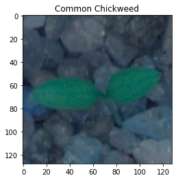

```python
# Display a random image from the actual images dataframe
display_random_images(df, 1)
```

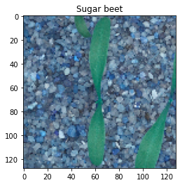

```python
# Display a random image from the normalized images dataframe
display_random_images(normalized_df, 1)
```

#### Observations:

2) Thus, we will use the normalized dataframe images for training our neural networks model.

## 2. Data preprocessing

```python
# A. To create X and Y from the DataFrame, we can use the 'img' column as X and 'species' column as Y.
X = np.array(normalized_df['img'].tolist())
Y = np.array(normalized_df['species'].to_list())
```

```python
# Checking X and Y shapes
print("Shape of X: ", X.shape)
print("Shape of Y: ",Y.shape)
```

```
Shape of X:  (4750, 128, 128, 3)
Shape of Y:  (4750,)
```

```python
# B. To encode the labels of the images, we can use LabelEncoder from scikit-learn library.
# Encode the labels to integers
label_encoder = LabelEncoder()
Y = label_encoder.fit_transform(Y)

#  one hot encode outputs to convert into binary vectors for training neural networks
Y = to_categorical(Y)
```

```python
# D. Normalise all the images:
# Convert the pixel values to floats between 0 and 1
#X = np.array(X) / 255.0
#X = StandardScaler().fit_transform(X)
```

```python
# Checking X and Y shapes after encoding the Target
print("Shape of X: ", X.shape)
print("Shape of Y after encoding the Target: ",Y.shape)
```

```
Shape of X:  (4750, 128, 128, 3)
Shape of Y after encoding the Target:  (4750, 12)
```

```python
# Print total Number of classes in the Dataset.
num_classes = Y.shape[1]
print("The number of classes in this dataset are:", num_classes)
```

```
The number of classes in this dataset are: 12
```

## 3. Model training

```python
# A.	Split the data into train and test data.
X_train, X_test, Y_train, Y_test = train_test_split(X, Y, test_size=0.2, random_state=42)
```

```python
# Print shape of all the 4 data split into x, y, train, test to verify if x & y are in sync.
print('Shape of X_train: ', X_train.shape)
print('Shape of Y_train: ', Y_train.shape)
print('Shape of X_test: ', X_test.shape)
print('Shape of X_test: ', Y_test.shape)
```

```
Shape of X_train:  (3800, 128, 128, 3)
Shape of Y_train:  (3800, 12)
Shape of X_test:  (950, 128, 128, 3)
Shape of X_test:  (950, 12)
```

```python
# B.	Create new CNN architecture to train the model.

# Base model
# Define the CNN model 1

model = Sequential([
    Conv2D(32, (3,3), activation='relu', input_shape=(128, 128, 3)),
    MaxPooling2D((2,2)),  # for feature localization(detection)
    Conv2D(64, (3,3), activation='relu'),
    MaxPooling2D((2,2)),
    Conv2D(128, (3,3), activation='relu'),
    MaxPooling2D((2,2)),
    Conv2D(256, (3,3), activation='relu'),
    GlobalAveragePooling2D(), # reduce the dimensionality of the feature map for overall pattern
    Flatten(),
    Dense(128, activation='relu'),
    Dense(12, activation='softmax') # making predictions(classification here)
])

# Compile the model
adam = optimizers.Adam(lr = 1e-3)
model.compile(optimizer=adam, loss='categorical_crossentropy', metrics=['accuracy'])
model.summary()

# Define callbacks
early_stop = EarlyStopping(monitor='val_loss', patience=3, restore_best_weights=True)
reduce_lr = ReduceLROnPlateau(monitor='val_loss', patience=2, factor=0.1, min_lr=0.00001)

# C.	Train the model on train data and validate on test data.
# Train the model
CNN_model_1 = model.fit(X_train, Y_train, epochs=20, batch_size=64, validation_data=(X_test, Y_test), shuffle=True, callbacks=[early_stop, reduce_lr], verbose = 2)

# Evaluate the model on train data
train_loss, train_acc = model.evaluate(X_train, Y_train)
print('*' * 50)
print('Model Performance metrics on train data')
print('*' * 50)
print('Train loss:', train_loss)
print('Train accuracy:', train_acc)

# Evaluate the model on test data
test_loss, test_acc = model.evaluate(X_test, Y_test)
print('*' * 50)
print('Model Performance metrics on test data')
print('*' * 50)
print('Test loss:', test_loss)
print('Test accuracy:', test_acc)
print('*' * 50)
```

```
Model: "sequential"
_________________________________________________________________
 Layer (type)                Output Shape              Param #
=================================================================
 conv2d (Conv2D)             (None, 126, 126, 32)      896

 max_pooling2d (MaxPooling2D  (None, 63, 63, 32)       0
 )

 conv2d_1 (Conv2D)           (None, 61, 61, 64)        18496

 max_pooling2d_1 (MaxPooling  (None, 30, 30, 64)       0
 2D)

 conv2d_2 (Conv2D)           (None, 28, 28, 128)       73856

 max_pooling2d_2 (MaxPooling  (None, 14, 14, 128)      0
 2D)

 conv2d_3 (Conv2D)           (None, 12, 12, 256)       295168

 global_average_pooling2d (G  (None, 256)              0
 lobalAveragePooling2D)

 flatten (Flatten)           (None, 256)               0

 dense (Dense)               (None, 128)               32896

 dense_1 (Dense)             (None, 12)                1548

=================================================================
Total params: 422,860
Trainable params: 422,860
Non-trainable params: 0
_________________________________________________________________
60/60 - 12s - loss: 4.4312 - accuracy: 0.1866 - val_loss: 1.9899 - val_accuracy: 0.3684 - lr: 0.0010 - 12s/epoch - 202ms/step
60/60 - 2s - loss: 1.7651 - accuracy: 0.3858 - val_loss: 1.6013 - val_accuracy: 0.4432 - lr: 0.0010 - 2s/epoch - 29ms/step
60/60 - 2s - loss: 1.5140 - accuracy: 0.4592 - val_loss: 1.3622 - val_accuracy: 0.5074 - lr: 0.0010 - 2s/epoch - 33ms/step
60/60 - 2s - loss: 1.2549 - accuracy: 0.5634 - val_loss: 1.3201 - val_accuracy: 0.5337 - lr: 0.0010 - 2s/epoch - 30ms/step
60/60 - 2s - loss: 1.1834 - accuracy: 0.5887 - val_loss: 1.1255 - val_accuracy: 0.6147 - lr: 0.0010 - 2s/epoch - 29ms/step
60/60 - 2s - loss: 1.0426 - accuracy: 0.6453 - val_loss: 0.9972 - val_accuracy: 0.6653 - lr: 0.0010 - 2s/epoch - 29ms/step
60/60 - 2s - loss: 0.9955 - accuracy: 0.6574 - val_loss: 1.1139 - val_accuracy: 0.6221 - lr: 0.0010 - 2s/epoch - 29ms/step
60/60 - 2s - loss: 0.9263 - accuracy: 0.6845 - val_loss: 0.9474 - val_accuracy: 0.6842 - lr: 0.0010 - 2s/epoch - 29ms/step
60/60 - 2s - loss: 0.8786 - accuracy: 0.6887 - val_loss: 0.8747 - val_accuracy: 0.7000 - lr: 0.0010 - 2s/epoch - 29ms/step
60/60 - 2s - loss: 0.8093 - accuracy: 0.7142 - val_loss: 0.8712 - val_accuracy: 0.6905 - lr: 0.0010 - 2s/epoch - 32ms/step
60/60 - 2s - loss: 0.7908 - accuracy: 0.7326 - val_loss: 0.8642 - val_accuracy: 0.6905 - lr: 0.0010 - 2s/epoch - 30ms/step
60/60 - 2s - loss: 0.6871 - accuracy: 0.7632 - val_loss: 0.7805 - val_accuracy: 0.7326 - lr: 0.0010 - 2s/epoch - 29ms/step
60/60 - 2s - loss: 0.6924 - accuracy: 0.7639 - val_loss: 0.6708 - val_accuracy: 0.7695 - lr: 0.0010 - 2s/epoch - 29ms/step
60/60 - 2s - loss: 0.6173 - accuracy: 0.7897 - val_loss: 0.6149 - val_accuracy: 0.7884 - lr: 0.0010 - 2s/epoch - 29ms/step
60/60 - 2s - loss: 0.5854 - accuracy: 0.7961 - val_loss: 0.5814 - val_accuracy: 0.8074 - lr: 0.0010 - 2s/epoch - 29ms/step
60/60 - 2s - loss: 0.5465 - accuracy: 0.8147 - val_loss: 0.7313 - val_accuracy: 0.7526 - lr: 0.0010 - 2s/epoch - 29ms/step
60/60 - 2s - loss: 0.5087 - accuracy: 0.8258 - val_loss: 0.5853 - val_accuracy: 0.8021 - lr: 0.0010 - 2s/epoch - 29ms/step
60/60 - 2s - loss: 0.3822 - accuracy: 0.8721 - val_loss: 0.4828 - val_accuracy: 0.8400 - lr: 1.0000e-04 - 2s/epoch - 33ms/step
60/60 - 2s - loss: 0.3514 - accuracy: 0.8845 - val_loss: 0.4793 - val_accuracy: 0.8326 - lr: 1.0000e-04 - 2s/epoch - 30ms/step
60/60 - 2s - loss: 0.3470 - accuracy: 0.8847 - val_loss: 0.4855 - val_accuracy: 0.8421 - lr: 1.0000e-04 - 2s/epoch - 29ms/step
Model Performance metrics on train data
Train loss: 0.3346633315086365
Train accuracy: 0.8973684310913086
Model Performance metrics on test data
Test loss: 0.4855085611343384
Test accuracy: 0.8421052694320679
```

[figure not shown]

[figure not shown]

```python
# Plot the training loss, validation loss vs number of epochs and training accuracy, validation accuracy vs number of epochs plot and write your observations on the same.
accuracy      = CNN_model_1.history['accuracy']
val_accuracy  = CNN_model_1.history['val_accuracy']
loss     = CNN_model_1.history['loss']
val_loss = CNN_model_1.history['val_loss']

epochs   = range(len(accuracy)) # Get number of epochs

plt.plot( epochs, loss, label = 'training loss' )
plt.plot( epochs, val_loss, label = 'validation loss' )
plt.legend(loc = 'upper right')
plt.title ('Training and validation loss'   )
plt.figure();

plt.plot( epochs, accuracy, label = 'training accuracy' )
plt.plot( epochs, val_accuracy, label = 'validation accuracy' )
plt.title('Training and validation accuracy')
plt.legend(loc = 'lower right')
plt.figure();
```

#### Observations:

1) The CNN model has achieved a train accuracy of 89.73% and a test accuracy of 84.21%.

3) Since our dataset is small, we can train our model on top of a Transfer Learning model that has been pre-trained on a large dataset and to improve performance. We can use the weights of the transfer learning model.

4) We can also use a larger batch size to achieve faster convergence on training data and therfore, reduce noise and overfitting on test data. But, it will lead to increased training time per epoch.

```python
# B.	Create new CNN architecture to train the model.

# Tranfer learning for Feature Extraction
# ResNet50 based CNN model
# Define the CNN model 2

import numpy as np
from keras.applications import ResNet50
from keras.models import Sequential
from keras.layers import Dense, Flatten, Dropout

# Define the ResNet50 model
resnet50 = ResNet50(include_top=False, weights='imagenet', input_shape=(128, 128, 3))

# Freeze the layers in the ResNet50 model
for layer in resnet50.layers:
    layer.trainable = False

# Create a new model based on ResNet50 and add new layers
model = Sequential()
model.add(resnet50)
model.add(Flatten())
model.add(Dense(512, activation='relu'))
model.add(Dropout(0.5))
model.add(Dense(12, activation='softmax'))

# Compile the model
adam = optimizers.Adam(lr = 1e-3)
model.compile(optimizer=adam, loss='categorical_crossentropy', metrics=['accuracy'])
model.summary()

# Define callbacks
early_stop = EarlyStopping(monitor='val_loss', patience=3, restore_best_weights=True)
reduce_lr = ReduceLROnPlateau(monitor='val_loss', patience=2, factor=0.1, min_lr=0.00001)

# C.	Train the model on train data and validate on test data.
# Train the model
CNN_model_2 = model.fit(X_train, Y_train, epochs=20, batch_size=128, validation_data=(X_test, Y_test), shuffle=True, callbacks=[early_stop, reduce_lr], verbose = 2)

# Evaluate the model on train data
train_loss, train_acc = model.evaluate(X_train, Y_train)
print('*' * 50)
print('Model Performance metrics on train data')
print('*' * 50)
print('Train loss:', train_loss)
print('Train accuracy:', train_acc)

# Evaluate the model on test data
test_loss, test_acc = model.evaluate(X_test, Y_test)
print('*' * 50)
print('Model Performance metrics on test data')
print('*' * 50)
print('Test loss:', test_loss)
print('Test accuracy:', test_acc)
print('*' * 50)
```

```
Model: "sequential_10"
_________________________________________________________________
 Layer (type)                Output Shape              Param #
=================================================================
 resnet50 (Functional)       (None, 4, 4, 2048)        23587712

 flatten_10 (Flatten)        (None, 32768)             0

 dense_20 (Dense)            (None, 512)               16777728

 dropout_8 (Dropout)         (None, 512)               0

 dense_21 (Dense)            (None, 12)                6156

=================================================================
Total params: 40,371,596
Trainable params: 16,783,884
Non-trainable params: 23,587,712
_________________________________________________________________
30/30 - 10s - loss: 5.1916 - accuracy: 0.3768 - val_loss: 1.2064 - val_accuracy: 0.6200 - lr: 0.0010 - 10s/epoch - 319ms/step
30/30 - 5s - loss: 1.1568 - accuracy: 0.6105 - val_loss: 0.8496 - val_accuracy: 0.7274 - lr: 0.0010 - 5s/epoch - 163ms/step
30/30 - 5s - loss: 0.7889 - accuracy: 0.7266 - val_loss: 0.6601 - val_accuracy: 0.7789 - lr: 0.0010 - 5s/epoch - 179ms/step
30/30 - 5s - loss: 0.5901 - accuracy: 0.7971 - val_loss: 0.5910 - val_accuracy: 0.7895 - lr: 0.0010 - 5s/epoch - 179ms/step
30/30 - 5s - loss: 0.4670 - accuracy: 0.8434 - val_loss: 0.6266 - val_accuracy: 0.8084 - lr: 0.0010 - 5s/epoch - 175ms/step
30/30 - 5s - loss: 0.4031 - accuracy: 0.8616 - val_loss: 0.5324 - val_accuracy: 0.8084 - lr: 0.0010 - 5s/epoch - 171ms/step
30/30 - 5s - loss: 0.3331 - accuracy: 0.8866 - val_loss: 0.5426 - val_accuracy: 0.8200 - lr: 0.0010 - 5s/epoch - 162ms/step
30/30 - 5s - loss: 0.2959 - accuracy: 0.8976 - val_loss: 0.5056 - val_accuracy: 0.8305 - lr: 0.0010 - 5s/epoch - 179ms/step
30/30 - 5s - loss: 0.2852 - accuracy: 0.9018 - val_loss: 0.5522 - val_accuracy: 0.8232 - lr: 0.0010 - 5s/epoch - 157ms/step
30/30 - 5s - loss: 0.2726 - accuracy: 0.9100 - val_loss: 0.5359 - val_accuracy: 0.8242 - lr: 0.0010 - 5s/epoch - 167ms/step
30/30 - 6s - loss: 0.1894 - accuracy: 0.9326 - val_loss: 0.5026 - val_accuracy: 0.8442 - lr: 1.0000e-04 - 6s/epoch - 189ms/step
30/30 - 5s - loss: 0.1550 - accuracy: 0.9492 - val_loss: 0.5060 - val_accuracy: 0.8432 - lr: 1.0000e-04 - 5s/epoch - 165ms/step
30/30 - 5s - loss: 0.1473 - accuracy: 0.9474 - val_loss: 0.5029 - val_accuracy: 0.8484 - lr: 1.0000e-04 - 5s/epoch - 152ms/step
30/30 - 5s - loss: 0.1366 - accuracy: 0.9539 - val_loss: 0.5040 - val_accuracy: 0.8453 - lr: 1.0000e-05 - 5s/epoch - 172ms/step
Model Performance metrics on train data
Train loss: 0.024865619838237762
Train accuracy: 0.996052622795105
Model Performance metrics on test data
Test loss: 0.5026285648345947
Test accuracy: 0.8442105054855347
```

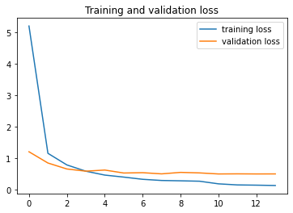

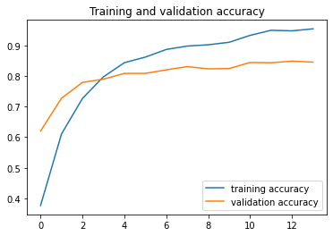

```python
# Plot the training loss, validation loss vs number of epochs and training accuracy, validation accuracy vs number of epochs plot and write your observations on the same.
accuracy      = CNN_model_2.history['accuracy']
val_accuracy  = CNN_model_2.history['val_accuracy']
loss     = CNN_model_2.history['loss']
val_loss = CNN_model_2.history['val_loss']

epochs   = range(len(accuracy)) # Get number of epochs

plt.plot( epochs, loss, label = 'training loss' )
plt.plot( epochs, val_loss, label = 'validation loss' )
plt.legend(loc = 'upper right')
plt.title ('Training and validation loss'   )
plt.figure();

plt.plot( epochs, accuracy, label = 'training accuracy' )
plt.plot( epochs, val_accuracy, label = 'validation accuracy' )
plt.title('Training and validation accuracy')
plt.legend(loc = 'lower right')
plt.figure();
```

#### Observations:

1) The CNN model has achieved a train accuracy of 99.60% and a test accuracy of 84.42%.

3) To further improve model peformance, we can use Data Augmentation along with a Transfer Learning model, and unfreeze some of the layers of the pre-trained model to allow for the weights to be updated during training.

4) Data Augmentation will further ensure that the model sees a different version of the same image in each epoch.

```python
# B.	Create new CNN architecture to train the model.

# # ResNet50 based hyper-tuned CNN model
# Define the CNN model 3

import numpy as np
from keras.applications import ResNet50
from keras.models import Sequential
from keras.layers import Dense, Flatten, Dropout
from keras import optimizers
from keras.callbacks import EarlyStopping, ReduceLROnPlateau
from keras.preprocessing.image import ImageDataGenerator

# Define the ResNet50 model
resnet50 = ResNet50(include_top=False, weights='imagenet', input_shape=(128, 128, 3))

# Freeze the layers in the ResNet50 model
for layer in resnet50.layers:
    layer.trainable = False

# Create a new model based on ResNet50 and add new layers
model = Sequential()
model.add(resnet50)
model.add(Flatten())
model.add(Dense(1024, activation='elu'))
model.add(Dropout(0.5))
model.add(Dense(512, activation='elu'))
#model.add(Dropout(0.5))
model.add(Dense(12, activation='softmax'))

# Fine-tune the last few layers of the ResNet50 model
for layer in resnet50.layers[-10:]:
    layer.trainable = True

# Define data generators with increased data augmentation
train_datagen = ImageDataGenerator(rotation_range=30,
                                   zoom_range=0.3,
                                   width_shift_range=0.2,
                                   height_shift_range=0.2,
                                   shear_range=0.2,
                                   horizontal_flip=True,
                                   fill_mode='nearest')

test_datagen = ImageDataGenerator()

train_generator = train_datagen.flow(X_train, Y_train, batch_size=128)
test_generator = test_datagen.flow(X_test, Y_test, batch_size=128)

# Adjust the learning rate
opt = optimizers.Adam(lr=0.001)
#opt = SGD(lr=0.01, momentum=0.9)
model.compile(optimizer=opt, loss='categorical_crossentropy', metrics=['accuracy'])
model.summary()

# Define callbacks
early_stop = EarlyStopping(monitor='val_loss', patience=3, restore_best_weights=True)
reduce_lr = ReduceLROnPlateau(monitor='val_loss', patience=2, factor=0.1, min_lr=0.00001)

# C.	Train the model on train data and validate on test data.
# Train the model
CNN_model_3 = model.fit(train_generator, epochs=20, steps_per_epoch=len(X_train)//128, validation_data=test_generator,
              validation_steps=len(X_test)//128,  shuffle=True, callbacks=[early_stop, reduce_lr], verbose = 2)

# Evaluate the model on train data
train_loss, train_acc = model.evaluate(X_train, Y_train)
print('*' * 50)
print('Model Performance metrics on train data')
print('*' * 50)
print('Train loss:', train_loss)
print('Train accuracy:', train_acc)

# Evaluate the model on test data
test_loss, test_acc = model.evaluate(X_test, Y_test)
print('*' * 50)
print('Model Performance metrics on test data')
print('*' * 50)
print('Test loss:', test_loss)
print('Test accuracy:', test_acc)
print('*' * 50)
```

```
Model: "sequential_14"
_________________________________________________________________
 Layer (type)                Output Shape              Param #
=================================================================
 resnet50 (Functional)       (None, 4, 4, 2048)        23587712

 flatten_14 (Flatten)        (None, 32768)             0

 dense_31 (Dense)            (None, 1024)              33555456

 dropout_12 (Dropout)        (None, 1024)              0

 dense_32 (Dense)            (None, 512)               524800

 dense_33 (Dense)            (None, 12)                6156

=================================================================
Total params: 57,674,124
Trainable params: 38,552,076
Non-trainable params: 19,122,048
_________________________________________________________________
29/29 - 21s - loss: 8.9041 - accuracy: 0.2247 - val_loss: 2.0322 - val_accuracy: 0.3493 - lr: 0.0010 - 21s/epoch - 725ms/step
29/29 - 17s - loss: 1.6586 - accuracy: 0.4382 - val_loss: 1.5793 - val_accuracy: 0.5089 - lr: 0.0010 - 17s/epoch - 569ms/step
29/29 - 17s - loss: 1.2541 - accuracy: 0.5542 - val_loss: 1.0216 - val_accuracy: 0.6685 - lr: 0.0010 - 17s/epoch - 571ms/step
29/29 - 16s - loss: 1.0723 - accuracy: 0.6258 - val_loss: 0.7149 - val_accuracy: 0.7545 - lr: 0.0010 - 16s/epoch - 568ms/step
29/29 - 17s - loss: 0.8696 - accuracy: 0.6904 - val_loss: 0.6763 - val_accuracy: 0.7857 - lr: 0.0010 - 17s/epoch - 588ms/step
29/29 - 16s - loss: 0.8335 - accuracy: 0.7146 - val_loss: 0.6501 - val_accuracy: 0.7768 - lr: 0.0010 - 16s/epoch - 568ms/step
29/29 - 16s - loss: 0.7560 - accuracy: 0.7330 - val_loss: 0.6953 - val_accuracy: 0.7835 - lr: 0.0010 - 16s/epoch - 559ms/step
29/29 - 18s - loss: 0.6744 - accuracy: 0.7639 - val_loss: 0.5110 - val_accuracy: 0.8158 - lr: 0.0010 - 18s/epoch - 612ms/step
29/29 - 16s - loss: 0.6238 - accuracy: 0.7821 - val_loss: 0.5249 - val_accuracy: 0.8225 - lr: 0.0010 - 16s/epoch - 552ms/step
29/29 - 16s - loss: 0.5712 - accuracy: 0.7990 - val_loss: 0.4448 - val_accuracy: 0.8415 - lr: 0.0010 - 16s/epoch - 566ms/step
29/29 - 17s - loss: 0.5671 - accuracy: 0.8023 - val_loss: 0.5162 - val_accuracy: 0.8248 - lr: 0.0010 - 17s/epoch - 572ms/step
29/29 - 16s - loss: 0.5328 - accuracy: 0.8186 - val_loss: 0.5371 - val_accuracy: 0.8292 - lr: 0.0010 - 16s/epoch - 546ms/step
29/29 - 17s - loss: 0.4830 - accuracy: 0.8306 - val_loss: 0.3619 - val_accuracy: 0.8694 - lr: 1.0000e-04 - 17s/epoch - 571ms/step
29/29 - 16s - loss: 0.4041 - accuracy: 0.8625 - val_loss: 0.3492 - val_accuracy: 0.8672 - lr: 1.0000e-04 - 16s/epoch - 563ms/step
29/29 - 16s - loss: 0.3860 - accuracy: 0.8625 - val_loss: 0.3448 - val_accuracy: 0.8717 - lr: 1.0000e-04 - 16s/epoch - 565ms/step
29/29 - 16s - loss: 0.3871 - accuracy: 0.8606 - val_loss: 0.3583 - val_accuracy: 0.8638 - lr: 1.0000e-04 - 16s/epoch - 552ms/step
29/29 - 16s - loss: 0.3546 - accuracy: 0.8641 - val_loss: 0.3556 - val_accuracy: 0.8761 - lr: 1.0000e-04 - 16s/epoch - 557ms/step
29/29 - 17s - loss: 0.3679 - accuracy: 0.8706 - val_loss: 0.3552 - val_accuracy: 0.8705 - lr: 1.0000e-05 - 17s/epoch - 574ms/step
Model Performance metrics on train data
Train loss: 0.24729202687740326
Train accuracy: 0.9131578803062439
Model Performance metrics on test data
Test loss: 0.3459477126598358
Test accuracy: 0.8705263137817383
```

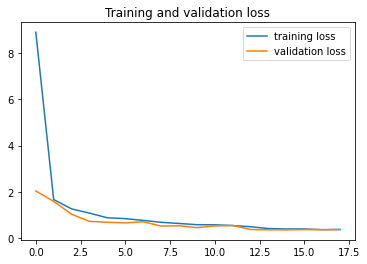

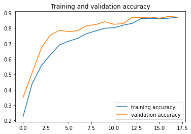

```python
# Plot the training loss, validation loss vs number of epochs and training accuracy, validation accuracy vs number of epochs plot and write your observations on the same.
accuracy      = CNN_model_3.history['accuracy']
val_accuracy  = CNN_model_3.history['val_accuracy']
loss     = CNN_model_3.history['loss']
val_loss = CNN_model_3.history['val_loss']

epochs   = range(len(accuracy)) # Get number of epochs

plt.plot( epochs, loss, label = 'training loss' )
plt.plot( epochs, val_loss, label = 'validation loss' )
plt.legend(loc = 'upper right')
plt.title ('Training and validation loss'   )
plt.figure();

plt.plot( epochs, accuracy, label = 'training accuracy' )
plt.plot( epochs, val_accuracy, label = 'validation accuracy' )
plt.title('Training and validation accuracy')
plt.legend(loc = 'lower right')
plt.figure();
```

#### Observations:

1) The CNN model has achieved a train accuracy of 91.31% and a test accuracy of 87.05%.

2) The train loss vs test loss stays consistent over successive epochs.

3) Comparing the train vs test accuracy, the model performs better on test data for most epochs before finally converging with the training accuarcy.

4) Overall, we can say that the model is well generalized and has not overfit on train data.

```python
# D.	Select a random image and print actual label and predicted label for the same.
#from keras.preprocessing import image
import keras.utils as image


# Load the image
img = X[0]

# Resize the image
img = cv2.resize(img, (128, 128))

# Preprocess the image
img = image.img_to_array(img)
img = img / 255.0
img = np.expand_dims(img, axis=0)

# Get the actual label of the image
actual_label =  np.argmax(Y[0])

# Use the best performing model to predict the label of the image
predicted_class = model.predict(img)
predicted_label = np.argmax(predicted_class)
print('Actual label for the test image is:', actual_label)
predicted_label = np.argmax(predicted_class)
print('Predicted label for the test image is:', predicted_label)
```

```
Actual label for the test image is: 11
Predicted label for the test image is: 6
```

#### Observations:

1) The model has made an incorrect prediction for the test image.

2) We need to further tune the model parameters to be able to make correct predictions.

## Part B

• DOMAIN: Botanical Research • CONTEXT: University X is currently undergoing some research involving understanding the characteristics of flowers. They already have have invested on curating sample images. They require an automation which can create a classifier capable of determining a flower’s species from a photo. • DATA DESCRIPTION: The dataset comprises of images from 17 plant species. • PROJECT OBJECTIVE: To experiment with various approaches to train an image classifier to predict type of flower from the image. Steps and tasks: [ Total Score: 30 Marks]

1. Import and Understand the data [5 Marks] A. Import and read oxflower17 dataset from tflearn and split into X and Y while loading. [2 Marks] Hint: It can be imported from tflearn.datasets. If tflearn is not installed, install it. It can be loaded using: x, y = oxflower17.load_data() B. Print Number of images and shape of the images. [1 Marks] C. Print count of each class from y. [2 Marks]
1. Image Exploration & Transformation [Learning purpose - Not related to final model] [10 Marks] A. Display 5 random images. [1 Marks] B. Select any image from the dataset and assign it to a variable. [1 Marks] C. Transform the image into grayscale format and display the same. [3 Marks] D. Apply a filter to sharpen the image and display the image before and after sharpening. [2 Marks] E. Apply a filter to blur the image and display the image before and after blur. [2 Marks] F. Display all the 4 images from above questions besides each other to observe the difference. [1 Marks]
1. Model training and Tuning: [15 Marks] A. Split the data into train and test with 80:20 proportion. [2 Marks] B. Train a model using any Supervised Learning algorithm and share performance metrics on test data. [3 Marks] C. Train a model using Neural Network and share performance metrics on test data. [4 Marks] D. Train a model using a basic CNN and share performance metrics on test data. [4 Marks] E. Predict the class/label of image ‘Prediction.jpg’ using best performing model and share predicted label. [2 Marks]

## 1. Import and Understand the data

```python
# A.	Import and read oxflower17 dataset from tflearn and split into X and Y while loading.
import tflearn.datasets.oxflower17 as oxflower17
#X, Y = oxflower17.load_data(one_hot = True)
X, Y = oxflower17.load_data()
```

```
WARNING:tensorflow:From /usr/local/lib/python3.9/dist-packages/tensorflow/python/compat/v2_compat.py:107: disable_resource_variables (from tensorflow.python.ops.variable_scope) is deprecated and will be removed in a future version.
Instructions for updating:
non-resource variables are not supported in the long term
```

```
Downloading Oxford 17 category Flower Dataset, Please wait...
```

```
100.0% 60276736 / 60270631
```

```
Succesfully downloaded 17flowers.tgz 60270631 bytes.
File Extracted
Starting to parse images...
Parsing Done!
```

```python
# Understanding the input images Central Tendancy
X.min(), X.max(), X.mean(), np.median(X), np.std(X)
```

```
(0.0, 1.0, 0.37326035, 0.32156864, 0.27128598)
```

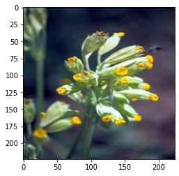

```python
# Display a randon image
plt.imshow(X[100])
plt.show()
```

```python
# Normalize the input images using MinMaxScaler
# X_mm = (X - X.min()) / (X.max() - X.min())
mm = MinMaxScaler(feature_range = (0, 1))
X_mm = mm.fit_transform(X)
```

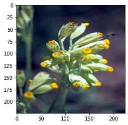

```python
# Display a randon image after MinMaxScaler normalization
plt.imshow(X_mm[100])
plt.show()
```

```python
# Normalize the input images using StandardScaler
# X_s = (X - np.mean(X)) / np.std(X)
s = StandardScaler()
X_s = s.fit_transform(X)
```

```
WARNING:matplotlib.image:Clipping input data to the valid range for imshow with RGB data ([0..1] for floats or [0..255] for integers).
```

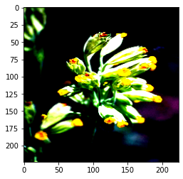

```python
# Display a randon image after StandardScaler normalization
plt.imshow(X_s[100])
plt.show()
```

```python
# Normalize the input images by dividing by the max pixel value
X_n = X/255.0
```

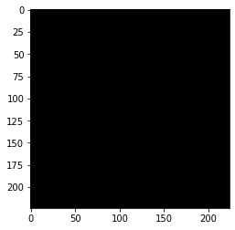

```python
# Display a randon image after Normalization
plt.imshow(X_n[100])
plt.show()
```

#### Observations:

1) The default input images and the input images normalized using MinMaxScaler() look almost identical.

2) The input images normalized using StandardScaler() are really high in contrast and are losing image information due to darkening.

3) The input images normalized by dividing by the max pixel value of 255 completely lose information and are totally black.

4) We are going to proceed with the input images normalized using MinMaxScaler() for the oxflower17 dataset to train our models.

```python
# Checking X and Y shapes
print("Shape of X: ", X.shape)
print("Shape of Y: ",Y.shape)
```

```
Shape of X:  (1360, 224, 224, 3)
Shape of Y:  (1360,)
```

```python
# Checking X and Y object types
print('Object type of X: ',type(X))
print('Object type of Y: ',type(Y))
```

```
Object type of X:  <class 'numpy.ndarray'>
Object type of Y:  <class 'numpy.ndarray'>
```

```python
# B.	Print Number of images and shape of the images.
print(f"Number of images: {len(X)}")
print(f"Shape of images: {X[0].shape}")
```

```
Number of images: 1360
Shape of images: (224, 224, 3)
```

```python
# C.	Print count of each class from y.
class_counts = np.sum(Y, axis = 0)
for i, count in enumerate(class_counts):
    print(f"Class {i+1} count: {count}")
```

[output not shown]

## 2. Image Exploration & Transformation

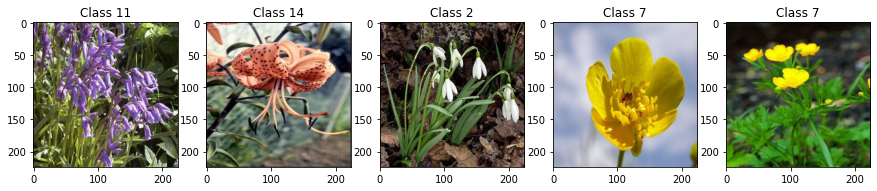

```python
# A.	Display 5 random images
fig, axes = plt.subplots(1, 5, figsize = (15, 3))
for i, ax in enumerate(axes):
    idx = random.randint(0, len(X)-1)
    ax.imshow(X[idx])
    ax.set_title(f"Class {np.argmax(Y[idx])+1}")
plt.show()
```

```python
# B. Select any image from the dataset and assign it to a variable.
#test_image
test_image = X[0]
```

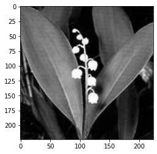

```python
# C. Transform the image into grayscale format and display the same.
test_image_gray = cv2.cvtColor(test_image, cv2.COLOR_RGB2GRAY)
plt.imshow(test_image_gray, cmap = 'gray')
plt.show();
```

```
WARNING:matplotlib.image:Clipping input data to the valid range for imshow with RGB data ([0..1] for floats or [0..255] for integers).
```

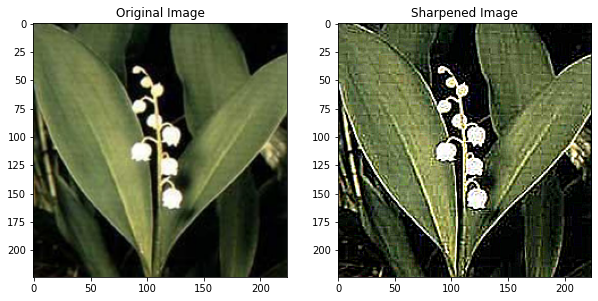

```python
# D. Apply a filter to sharpen the image and display the image before and after sharpening.
sharpen_kernel = np.array([[-1,-1,-1], [-1,9,-1], [-1,-1,-1]])
test_image_sharpened = cv2.filter2D(test_image, -1, sharpen_kernel)

fig, axes = plt.subplots(1, 2, figsize = (10, 5))
axes[0].imshow(test_image)
axes[0].set_title("Original Image")
axes[1].imshow(test_image_sharpened)
axes[1].set_title("Sharpened Image")
plt.show();
```

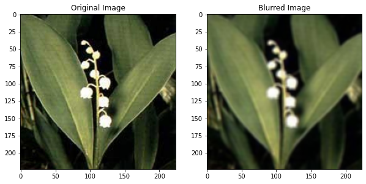

```python
# E. Apply a filter to blur the image and display the image before and after blur.
blur_kernel = np.ones((5,5),np.float32)/25
test_image_blurred = cv2.filter2D(test_image, -1, blur_kernel)

fig, axes = plt.subplots(1, 2, figsize = (10, 5))
axes[0].imshow(test_image)
axes[0].set_title("Original Image")
axes[1].imshow(test_image_blurred)
axes[1].set_title("Blurred Image")
plt.show();
```

```
WARNING:matplotlib.image:Clipping input data to the valid range for imshow with RGB data ([0..1] for floats or [0..255] for integers).
```

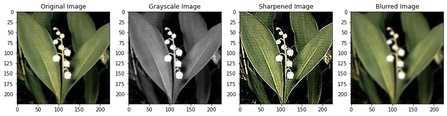

```python
# F. Display all the 4 images from above questions besides each other to observe the difference.
fig, axes = plt.subplots(1, 4, figsize = (15, 5))
axes[0].imshow(test_image)
axes[0].set_title("Original Image")
axes[1].imshow(test_image_gray, cmap = 'gray')
axes[1].set_title("Grayscale Image")
axes[2].imshow(test_image_sharpened)
axes[2].set_title("Sharpened Image")
axes[3].imshow(test_image_blurred)
axes[3].set_title("Blurred Image");
```

```python
# Reshape & normalise the images for Supervised Models
X1 = np.array(X).reshape(len(X), 150528)/255.0

# Assign the target to a new variable for Supervised Models
Y1 = Y # Target class is already endcoded

# Normalise the images for Neural Networks
#X = np.array(X)/255.0

# Encode the labels to binary vectors for Neural Networks
Y = to_categorical(Y)
```

```python
# Checking X and Y shapes
print('Shape of X1 for Supervised Models: ',X1.shape)
print('Shape of Y1 for Supervised Models: ',Y1.shape)
print('Shape of X for Neural Networks: ',X.shape)
print('Shape of Y for Neural Networks: ',Y.shape)
```

```
Shape of X1 for Supervised Models:  (1360, 150528)
Shape of Y1 for Supervised Models:  (1360,)
Shape of X for Neural Networks:  (1360, 224, 224, 3)
Shape of Y for Neural Networks:  (1360, 17)
```

```python
# Checking X and Y object types
print('Object type of X1 for Supervised Models: ',type(X1))
print('Object type of Y1 for Supervised Models: ',type(Y1))
print('Object type of X for Neural Networks: ',type(X))
print('Object type of Y for Neural Networks: ',type(Y))
```

```
Object type of X1 for Supervised Models:  <class 'numpy.ndarray'>
Object type of Y1 for Supervised Models:  <class 'numpy.ndarray'>
Object type of X for Neural Networks:  <class 'numpy.ndarray'>
Object type of Y for Neural Networks:  <class 'numpy.ndarray'>
```

```python
# Carry out dimensionality reduction
pca = PCA(0.99) # reduce the number of features in X while retaining as much information as possible
X1_PCA  = pca.fit_transform(X1)
print(X1_PCA.shape)
```

```
(1360, 1083)
```

#### Observations:

1) We have reduced the number of features for X from 150528 to 1083. This should in turn improve model performance and compute time.

## 3. Model training and Tuning:

```python
# B. Train a model using any Supervised Learning algorithm and share performance metrics on test data:
def train_test_model(model, X, y, test_size=0.2, random_state=42):
    # Split the data into training and test sets
    X_train, X_test, y_train, y_test = train_test_split(X, y, test_size=test_size, random_state=random_state)

    # Print the shape of the training and test sets
    print("Dataset shape:")
    print("*" * 50)
    print("Shape of Training Data: ", X_train.shape)
    print("Shape of Test Data: ", X_test.shape)
    print("*" * 50)

    # assign the user defined model
    model = model

    # Train the model on the training data
    model.fit(X_train, y_train)

    # Predict the labels for the test data
    y_pred = model.predict(X_test)

    # Classification Accuracy
    print("Model Classification Accuracy:")
    print("*" * 50)
    print('Accuracy on Training data is', model.score(X_train, y_train))
    print('Accuracy on Test data is', model.score(X_test, y_test))
    print("*" * 50)

    # Print the classification report and confusion matrix
    print("\nClassification Report:\n")
    print("*" * 50)
    print(classification_report(y_test, y_pred))
    print("*" * 50)

    print("\nConfusion Matrix:\n")
    print("*" * 50)
    cm = confusion_matrix(y_test, y_pred)
    plt.figure(figsize = (7,5))
    sns.heatmap(cm, annot=True, cmap="rainbow")
    plt.show()
```

```
Dataset shape:
Shape of Training Data:  (952, 1083)
Shape of Test Data:  (408, 1083)
Model Classification Accuracy:
Accuracy on Training data is 0.4831932773109244
Accuracy on Test data is 0.3088235294117647

Classification Report:

              precision    recall  f1-score   support

           0       0.00      0.00      0.00        32
           1       0.67      0.08      0.14        26
           2       0.34      0.86      0.49        22
           3       0.00      0.00      0.00        27
           4       0.31      0.76      0.44        25
           5       0.11      0.05      0.07        20
           6       0.33      0.11      0.16        28
           7       0.00      0.00      0.00        30
           8       0.60      0.50      0.55        24
           9       0.24      0.76      0.37        21
          10       0.27      0.25      0.26        24
          11       0.37      0.46      0.41        24
          12       0.26      0.60      0.36        20
          13       0.17      0.05      0.07        22
          14       0.17      0.20      0.19        20
          15       0.14      0.05      0.07        22
          16       0.41      0.90      0.57        21

    accuracy                           0.31       408
   macro avg       0.26      0.33      0.24       408
weighted avg       0.25      0.31      0.23       408


Confusion Matrix:
```

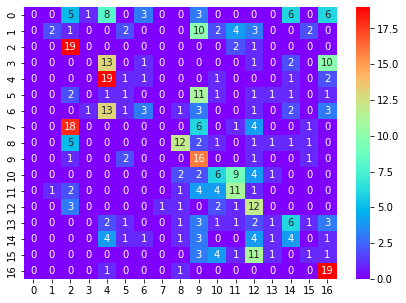

```python
# Call the Supervised Learning model
train_test_model(LogisticRegression(), X1_PCA, Y1, test_size=0.3, random_state=42)
```

```
LogR: 0.350735 (0.031031)
KNN: 0.305882 (0.020056)
NB: 0.205147 (0.028939)
SVM-rbf: 0.413235 (0.039295)
D-Tree: 0.271324 (0.047476)
RF: 0.334559 (0.033575)
XGB: 0.408088 (0.034839)
```

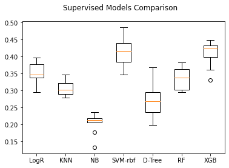

```python
# K-Fold CV for finding best Supervised Learning model
LogR_model = LogisticRegression(C=1, penalty='l2', solver='liblinear') # default parameter settings
KNN_model = KNeighborsClassifier(n_neighbors=7, weights='uniform', algorithm='auto')
GN_model = GaussianNB()
svc_model_rbf = SVC(kernel='rbf', degree=2, C=10, gamma=0.1)
DT_model = DecisionTreeClassifier(criterion='gini', max_depth=5, min_samples_leaf=5)
RF_model = RandomForestClassifier(n_estimators=100, max_features='sqrt', max_depth=10)
XGB_model = XGBClassifier(n_estimators=100, learning_rate=0.1, max_depth=5, subsample=1, colsample_bytree=1, gamma=0, reg_alpha=0, reg_lambda=1) # default max_depth = 3

seed = 1
# prepare models
models = []
models.append(('LogR', LogR_model))
models.append(('KNN', KNN_model))
models.append(('NB', GN_model))
models.append(('SVM-rbf', svc_model_rbf))
models.append(('D-Tree', DT_model))
models.append(('RF', RF_model))
models.append(('XGB', XGB_model))

# evaluate each model in turn
results = []
names = []
scoring = 'accuracy'
for name, model in models:
    kfold = model_selection.KFold(n_splits = 10, random_state = seed, shuffle = True)
    cv_results = model_selection.cross_val_score(model, X1_PCA, Y1, cv = kfold, scoring = scoring)
    results.append(cv_results)
    names.append(name)
    msg = "%s: %f (%f)" % (name, cv_results.mean(), cv_results.std())
    print(msg)

# boxplot algorithm comparison
fig = plt.figure()
fig.suptitle('Supervised Models Comparison')
ax = fig.add_subplot(111)
plt.boxplot(results)
ax.set_xticklabels(names)
plt.show()
```

#### Observations:

1) We have trained several hyper-tuned Supervised Learning models and validated using K-fold cross valition to find the best performing model.

2) The best performing models are --> SVM-rbf Classifier > XGB Classifier > Logistic regression.

3) The XGB classifier almost has similar accuracy to the SVM-rbf Classifier, but it also has the longest computation time of all the models.

4) Therfore, we can use the SVM-rbf Classifier on this dataset, since it has the best model performance and compute time is also less.

```python
# A. Split the data into train and test with 80:20 proportion:
X_train, X_test, y_train, y_test = train_test_split(X_mm, Y, test_size = 0.2, random_state = 42)
```

```python
# Print shape of all the 4 data split into x, y, train, test to verify if x & y is in sync.
print(X_train.shape)
print(y_train.shape)
print(X_test.shape)
print(y_test.shape)
```

```
(1088, 224, 224, 3)
(1088, 17)
(272, 224, 224, 3)
(272, 17)
```

```python
# C. Train a model using Neural Network and share performance metrics on test data:

# Define the neural network model
model = Sequential()
model.add(Flatten())
model.add(Dense(32, activation = 'elu')) ###Multiple Dense units with elu activation
model.add(Dense(64, activation = 'elu'))
model.add(Dense(128, activation = 'elu'))
model.add(Dense(512, activation = 'elu'))
model.add(Dropout(0.5))
model.add(Dense(256, activation = 'elu'))
model.add(Dense(17, activation = 'softmax'))

# Build the model
model.build(input_shape=(None, 224, 224, 3))

# Compile the model
adam = optimizers.Adam(lr = 1e-3)
model.compile(optimizer=adam, loss='categorical_crossentropy', metrics=['accuracy'])
model.summary()

# Train the model
early_stop = EarlyStopping(monitor='val_loss', patience=3, restore_best_weights=True)
reduce_lr  = ReduceLROnPlateau(monitor = 'val_loss', patience = 2, factor = 0.1, min_lr = 0.00001, model = 'auto')
NN_classifier = model.fit(X_train, y_train, epochs=20, batch_size=32, validation_data=(X_test, y_test),  shuffle=True, callbacks=[early_stop, reduce_lr], verbose = 2)

# Evaluate the model on train data
train_loss, train_acc = model.evaluate(X_train, y_train)
print('*' * 50)
print('Model Performance metrics on train data')
print('*' * 50)
print('Train loss:', train_loss)
print('Train accuracy:', train_acc)

# Evaluate the model on test data
test_loss, test_acc = model.evaluate(X_test, y_test)
print('*' * 50)
print('Model Performance metrics on test data')
print('*' * 50)
print('Test loss:', test_loss)
print('Test accuracy:', test_acc)
print('*' * 50)
```

```
Model: "sequential_7"
_________________________________________________________________
 Layer (type)                Output Shape              Param #
=================================================================
 flatten_7 (Flatten)         multiple                  0

 dense_42 (Dense)            multiple                  4816928

 dense_43 (Dense)            multiple                  2112

 dense_44 (Dense)            multiple                  8320

 dense_45 (Dense)            multiple                  66048

 dropout_7 (Dropout)         multiple                  0

 dense_46 (Dense)            multiple                  131328

 dense_47 (Dense)            multiple                  4369

=================================================================
Total params: 5,029,105
Trainable params: 5,029,105
Non-trainable params: 0
_________________________________________________________________
Train on 1088 samples, validate on 272 samples
1088/1088 - 1s - loss: 5.2779 - acc: 0.0689 - val_loss: 2.5832 - val_acc: 0.1471 - lr: 0.0010 - 1s/epoch - 1ms/sample
1088/1088 - 1s - loss: 2.5629 - acc: 0.1544 - val_loss: 2.3051 - val_acc: 0.2096 - lr: 0.0010 - 911ms/epoch - 837us/sample
1088/1088 - 1s - loss: 2.4000 - acc: 0.2086 - val_loss: 2.3702 - val_acc: 0.1360 - lr: 0.0010 - 863ms/epoch - 793us/sample
1088/1088 - 1s - loss: 2.2738 - acc: 0.1985 - val_loss: 2.0975 - val_acc: 0.2353 - lr: 0.0010 - 784ms/epoch - 720us/sample
1088/1088 - 1s - loss: 2.3077 - acc: 0.2215 - val_loss: 2.2358 - val_acc: 0.1765 - lr: 0.0010 - 823ms/epoch - 757us/sample
1088/1088 - 1s - loss: 2.1659 - acc: 0.2335 - val_loss: 2.2102 - val_acc: 0.2463 - lr: 0.0010 - 920ms/epoch - 845us/sample
1088/1088 - 1s - loss: 2.0200 - acc: 0.2831 - val_loss: 2.1276 - val_acc: 0.2206 - lr: 1.0000e-04 - 798ms/epoch - 734us/sample
Model Performance metrics on train data
Train loss: 2.0008452990475822
Train accuracy: 0.26838234
Model Performance metrics on test data
Test loss: 2.097530252793256
Test accuracy: 0.23529412
```

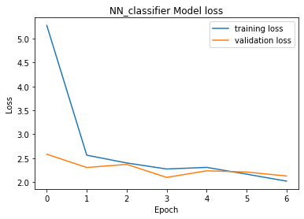

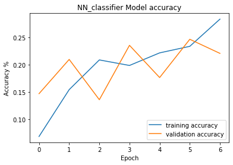

```python
# Plot the training loss, validation loss vs number of epochs and training accuracy, validation accuracy vs number of epochs plot and write your observations on the same.
accuracy      = NN_classifier.history['acc']
val_accuracy  = NN_classifier.history['val_acc']
loss     = NN_classifier.history['loss']
val_loss = NN_classifier.history['val_loss']

epochs   = NN_classifier.epoch # Get number of epochs

plt.xlabel('Epoch')
plt.ylabel('Loss')
plt.plot( epochs, loss, label = 'training loss' )
plt.plot( epochs, val_loss, label = 'validation loss' )
plt.legend(loc = 'upper right')
plt.title ('NN_classifier Model loss'   )
plt.figure();


plt.xlabel('Epoch')
plt.ylabel('Accuracy %')
plt.plot( epochs, accuracy, label = 'training accuracy' )
plt.plot( epochs, val_accuracy, label = 'validation accuracy' )
plt.title('NN_classifier Model accuracy')
plt.legend(loc = 'lower right')
plt.figure();
```

#### Observations:

1) The Neural Network model test accuracy of 23.52% is significantly less than the Supervised Learning model(SVM-rbf classifier - 41.32%).

```python
# D.	Train a model using a basic CNN and share performance metrics on test data.

# Define the CNN model
model = Sequential([
    Conv2D(32, (3,3), activation='elu', input_shape=(224, 224, 3)),
    MaxPooling2D((2,2)),  # for feature localization(detection)
    Conv2D(64, (3,3), activation='elu'),
    MaxPooling2D((2,2)),
    Conv2D(128, (3,3), activation='elu'),
    MaxPooling2D((2,2)),
    Conv2D(256, (3,3), activation='elu'),
    GlobalAveragePooling2D(), # reduce the dimensionality of the feature map for overall pattern identification
    Flatten(),
    Dense(128, activation='elu'),
    Dropout(0.5),  # Adding dropout after the first fully connected layer
    Dense(17, activation='softmax') # making predictions(classification here)
])

# Compile the model
adam = optimizers.Adam(lr = 1e-3)
model.compile(optimizer=adam, loss='categorical_crossentropy', metrics=['accuracy'])
model.summary()

# Define callbacks
early_stop = EarlyStopping(monitor='val_loss', patience=3, restore_best_weights=True)
reduce_lr = ReduceLROnPlateau(monitor='val_loss', patience=2, factor=0.1, min_lr=0.00001)

# C.	Train the model on train data and validate on test data.
# Train the model
CNN_classifier_1 = model.fit(X_train, y_train, epochs=20, batch_size=32, validation_data=(X_test, y_test), shuffle=True, callbacks=[early_stop, reduce_lr], verbose = 2)

# Evaluate the model on train data
train_loss, train_acc = model.evaluate(X_train, y_train)
print('*' * 50)
print('Model Performance metrics on train data')
print('*' * 50)
print('Train loss:', train_loss)
print('Train accuracy:', train_acc)

# Evaluate the model on test data
test_loss, test_acc = model.evaluate(X_test, y_test)
print('*' * 50)
print('Model Performance metrics on test data')
print('*' * 50)
print('Test loss:', test_loss)
print('Test accuracy:', test_acc)
print('*' * 50)
```

```
Model: "sequential_9"
_________________________________________________________________
 Layer (type)                Output Shape              Param #
=================================================================
 conv2d_4 (Conv2D)           (None, 222, 222, 32)      896

 max_pooling2d_3 (MaxPooling  (None, 111, 111, 32)     0
 2D)

 conv2d_5 (Conv2D)           (None, 109, 109, 64)      18496

 max_pooling2d_4 (MaxPooling  (None, 54, 54, 64)       0
 2D)

 conv2d_6 (Conv2D)           (None, 52, 52, 128)       73856

 max_pooling2d_5 (MaxPooling  (None, 26, 26, 128)      0
 2D)

 conv2d_7 (Conv2D)           (None, 24, 24, 256)       295168

 global_average_pooling2d_1   (None, 256)              0
 (GlobalAveragePooling2D)

 flatten_9 (Flatten)         (None, 256)               0

 dense_50 (Dense)            (None, 128)               32896

 dropout_9 (Dropout)         (None, 128)               0

 dense_51 (Dense)            (None, 17)                2193

=================================================================
Total params: 423,505
Trainable params: 423,505
Non-trainable params: 0
_________________________________________________________________
Train on 1088 samples, validate on 272 samples
1088/1088 - 3s - loss: 2.6299 - acc: 0.1287 - val_loss: 2.4360 - val_acc: 0.1801 - lr: 0.0010 - 3s/epoch - 3ms/sample
1088/1088 - 2s - loss: 2.3690 - acc: 0.2022 - val_loss: 2.4406 - val_acc: 0.1765 - lr: 0.0010 - 2s/epoch - 2ms/sample
```

[output cut: 9 more lines]

```
1088/1088 - 2s - loss: 1.7056 - acc: 0.4301 - val_loss: 1.7324 - val_acc: 0.4669 - lr: 1.0000e-04 - 2s/epoch - 2ms/sample
1088/1088 - 2s - loss: 1.6875 - acc: 0.4439 - val_loss: 1.6988 - val_acc: 0.4890 - lr: 1.0000e-04 - 2s/epoch - 2ms/sample
1088/1088 - 2s - loss: 1.6810 - acc: 0.4210 - val_loss: 1.7117 - val_acc: 0.4669 - lr: 1.0000e-04 - 2s/epoch - 2ms/sample
1088/1088 - 2s - loss: 1.6684 - acc: 0.4513 - val_loss: 1.6775 - val_acc: 0.5000 - lr: 1.0000e-04 - 2s/epoch - 2ms/sample
1088/1088 - 2s - loss: 1.6088 - acc: 0.4651 - val_loss: 1.6597 - val_acc: 0.4926 - lr: 1.0000e-04 - 2s/epoch - 2ms/sample
1088/1088 - 2s - loss: 1.6254 - acc: 0.4706 - val_loss: 1.6392 - val_acc: 0.4963 - lr: 1.0000e-04 - 2s/epoch - 2ms/sample
1088/1088 - 2s - loss: 1.6244 - acc: 0.4476 - val_loss: 1.6412 - val_acc: 0.4926 - lr: 1.0000e-04 - 2s/epoch - 2ms/sample
1088/1088 - 2s - loss: 1.6215 - acc: 0.4660 - val_loss: 1.6461 - val_acc: 0.4963 - lr: 1.0000e-04 - 2s/epoch - 2ms/sample
1088/1088 - 2s - loss: 1.5835 - acc: 0.4752 - val_loss: 1.6365 - val_acc: 0.5037 - lr: 1.0000e-05 - 2s/epoch - 2ms/sample
Model Performance metrics on train data
Train loss: 1.427963460192961
Train accuracy: 0.5358456
Model Performance metrics on test data
Test loss: 1.636461664648617
Test accuracy: 0.5036765
```

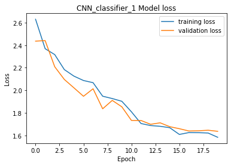

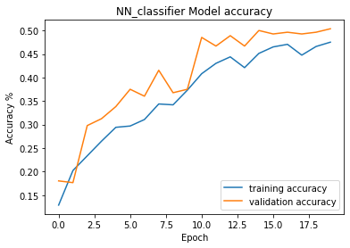

```python
# Plot the training loss, validation loss vs number of epochs and training accuracy, validation accuracy vs number of epochs plot and write your observations on the same.
accuracy      = CNN_classifier_1.history['acc']
val_accuracy  = CNN_classifier_1.history['val_acc']
loss     = CNN_classifier_1.history['loss']
val_loss = CNN_classifier_1.history['val_loss']

epochs   = CNN_classifier_1.epoch # Get number of epochs

plt.xlabel('Epoch')
plt.ylabel('Loss')
plt.plot( epochs, loss, label = 'training loss' )
plt.plot( epochs, val_loss, label = 'validation loss' )
plt.legend(loc = 'upper right')
plt.title ('CNN_classifier_1 Model loss'   )
plt.figure();


plt.xlabel('Epoch')
plt.ylabel('Accuracy %')
plt.plot( epochs, accuracy, label = 'training accuracy' )
plt.plot( epochs, val_accuracy, label = 'validation accuracy' )
plt.title('NN_classifier Model accuracy')
plt.legend(loc = 'lower right')
plt.figure();
```

#### Observations:

1) The basic CNN model test accuracy of 50.36% is much better than the Supervised Learning model(SVM-rbf classifier - 41.32%).

2) Overall, the model performance of both train-test data is similar.

3) With more epochs, the test performance of the model should further increase.

```python
# Train a model on a hyper-tuned CNN and share performance metrics on test data.

# Define the CNN model
model = Sequential()

# First convolutional layer
model.add(Conv2D(32, (3,3), activation='elu', input_shape=(224,224,3)))
model.add(MaxPooling2D((2,2)))
# Second convolutional layer
model.add(Conv2D(64, (3,3), activation='elu'))
model.add(MaxPooling2D((2,2)))
# Third convolutional layer
model.add(Conv2D(128, (3,3), activation='elu'))
model.add(MaxPooling2D((2,2)))
# Fourth convolutional layer
model.add(Conv2D(512, (3,3), activation='elu'))
model.add(MaxPooling2D((2,2)))
# Fifth convolutional layer
model.add(Conv2D(256, (3,3), activation='elu'))
model.add(GlobalAveragePooling2D()) # reduce the dimensionality of the feature map for overall pattern identification
# Flatten layer to stack output convolutions into 1D feature vectors
model.add(Flatten())
# Fully connected layer
model.add(Dense(128, activation='elu'))
# Dropout layer to reduce overfitting
#model.add(Dropout(0.5))
# Output layer
model.add(Dense(17, activation='softmax'))

# Compile the model
adam = optimizers.Adam(lr = 1e-3)
model.compile(optimizer=adam, loss='categorical_crossentropy', metrics=['accuracy'])
model.summary()

# Define callbacks
early_stop = EarlyStopping(monitor='val_loss', patience=3, restore_best_weights=True)
reduce_lr = ReduceLROnPlateau(monitor='val_loss', patience=2, factor=0.1, min_lr=0.00001)

# C.	Train the model on train data and validate on test data.
# Train the model
CNN_classifier_2 = model.fit(X_train, y_train, epochs=20, batch_size=32, validation_data=(X_test, y_test), shuffle=True, callbacks=[early_stop, reduce_lr], verbose = 2)

# Evaluate the model on train data
train_loss, train_acc = model.evaluate(X_train, y_train)
print('*' * 50)
print('Model Performance metrics on train data')
print('*' * 50)
print('Train loss:', train_loss)
print('Train accuracy:', train_acc)

# Evaluate the model on test data
test_loss, test_acc = model.evaluate(X_test, y_test)
print('*' * 50)
print('Model Performance metrics on test data')
print('*' * 50)
print('Test loss:', test_loss)
print('Test accuracy:', test_acc)
print('*' * 50)
```

```
Model: "sequential_10"
_________________________________________________________________
 Layer (type)                Output Shape              Param #
=================================================================
 conv2d_8 (Conv2D)           (None, 222, 222, 32)      896

 max_pooling2d_6 (MaxPooling  (None, 111, 111, 32)     0
 2D)

 conv2d_9 (Conv2D)           (None, 109, 109, 64)      18496

 max_pooling2d_7 (MaxPooling  (None, 54, 54, 64)       0
 2D)

 conv2d_10 (Conv2D)          (None, 52, 52, 128)       73856

 max_pooling2d_8 (MaxPooling  (None, 26, 26, 128)      0
 2D)

 conv2d_11 (Conv2D)          (None, 24, 24, 512)       590336

 max_pooling2d_9 (MaxPooling  (None, 12, 12, 512)      0
 2D)

 conv2d_12 (Conv2D)          (None, 10, 10, 256)       1179904

 global_average_pooling2d_2   (None, 256)              0
 (GlobalAveragePooling2D)

 flatten_10 (Flatten)        (None, 256)               0

 dense_52 (Dense)            (None, 128)               32896

 dense_53 (Dense)            (None, 17)                2193

=================================================================
Total params: 1,898,577
Trainable params: 1,898,577
Non-trainable params: 0
_________________________________________________________________
```

[output cut: 11 more lines]

```
1088/1088 - 2s - loss: 1.1137 - acc: 0.6296 - val_loss: 1.2034 - val_acc: 0.6140 - lr: 0.0010 - 2s/epoch - 2ms/sample
1088/1088 - 2s - loss: 1.1069 - acc: 0.6112 - val_loss: 1.3755 - val_acc: 0.5515 - lr: 0.0010 - 2s/epoch - 2ms/sample
1088/1088 - 2s - loss: 0.9922 - acc: 0.6719 - val_loss: 1.1400 - val_acc: 0.6066 - lr: 0.0010 - 2s/epoch - 2ms/sample
1088/1088 - 2s - loss: 0.9402 - acc: 0.6645 - val_loss: 1.1877 - val_acc: 0.6029 - lr: 0.0010 - 2s/epoch - 2ms/sample
1088/1088 - 3s - loss: 0.8407 - acc: 0.7096 - val_loss: 1.1898 - val_acc: 0.6176 - lr: 0.0010 - 3s/epoch - 2ms/sample
1088/1088 - 2s - loss: 0.6384 - acc: 0.7868 - val_loss: 0.8970 - val_acc: 0.7206 - lr: 1.0000e-04 - 2s/epoch - 2ms/sample
1088/1088 - 2s - loss: 0.5419 - acc: 0.8162 - val_loss: 0.9133 - val_acc: 0.7096 - lr: 1.0000e-04 - 2s/epoch - 2ms/sample
1088/1088 - 2s - loss: 0.5113 - acc: 0.8336 - val_loss: 0.9226 - val_acc: 0.7169 - lr: 1.0000e-04 - 2s/epoch - 2ms/sample
1088/1088 - 3s - loss: 0.4810 - acc: 0.8474 - val_loss: 0.9122 - val_acc: 0.7169 - lr: 1.0000e-05 - 3s/epoch - 3ms/sample
Model Performance metrics on train data
Train loss: 0.547797449371394
Train accuracy: 0.8180147
Model Performance metrics on test data
Test loss: 0.8970158731236177
Test accuracy: 0.7205882
```

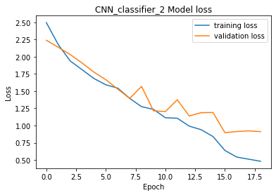

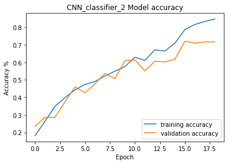

```python
# Plot the training loss, validation loss vs number of epochs and training accuracy, validation accuracy vs number of epochs plot and write your observations on the same.
accuracy      = CNN_classifier_2.history['acc']
val_accuracy  = CNN_classifier_2.history['val_acc']
loss     = CNN_classifier_2.history['loss']
val_loss = CNN_classifier_2.history['val_loss']

epochs   = range(len(accuracy)) # Get number of epochs

plt.xlabel('Epoch')
plt.ylabel('Loss')
plt.plot( epochs, loss, label = 'training loss' )
plt.plot( epochs, val_loss, label = 'validation loss' )
plt.legend(loc = 'upper right')
plt.title ('CNN_classifier_2 Model loss'   )
plt.figure();

plt.xlabel('Epoch')
plt.ylabel('Accuracy %')
plt.plot( epochs, accuracy, label = 'training accuracy' )
plt.plot( epochs, val_accuracy, label = 'validation accuracy' )
plt.title('CNN_classifier_2 Model accuracy')
plt.legend(loc = 'lower right')
plt.figure();
```

#### Observations:

1) The hyper-tuned CNN model with additional Convolutional layers performs even better with a test accuracy of 72.05% compared to the basic CNN model test accuracy(50.36%) and the Supervised Learning model(SVM-rbf classifier - 41.32%).

2) With more epochs, the test performance of the model should further improve close to train performance of the model.

```python
# D.	Train a CNN model on top of Transfer Learning and share performance metrics on test data.

import numpy as np
from keras.applications import VGG16
from keras.models import Sequential
from keras.layers import Dense, Flatten, Dropout
from keras import optimizers, regularizers
from keras.callbacks import EarlyStopping, ReduceLROnPlateau
from keras.preprocessing.image import ImageDataGenerator

# Define the CNN model
#Load the VGG model
vgg_conv = VGG16(weights='imagenet', include_top=False, input_shape=(224, 224, 3))

# Freeze the layers in the VGG16 model
for layer in vgg_conv.layers:
    layer.trainable = False

# Create a new model based on VGG16 and add new layers
model = Sequential()
model.add(vgg_conv)
model.add(Flatten())
model.add(Dense(1024, activation='elu'))
#model.add(Dropout(0.5))
model.add(Dense(512, activation='elu', kernel_regularizer=regularizers.l2(0.01)))
model.add(Dense(17, activation='softmax'))

# Freeze all the layers except for the last layer:
for layer in vgg_conv.layers[:-4]:
    layer.trainable = False

# Define data generators with increased data augmentation
train_datagen = ImageDataGenerator(rotation_range=30,
                                   zoom_range=0.3,
                                   width_shift_range=0.2,
                                   height_shift_range=0.2,
                                   shear_range=0.2,
                                   horizontal_flip=True,
                                   fill_mode='nearest')

test_datagen = ImageDataGenerator()

train_generator = train_datagen.flow(X_train, y_train, batch_size=32)
test_generator = test_datagen.flow(X_test, y_test, batch_size=32)

# Adjust the learning rate
opt = optimizers.Adam(lr=0.0001)
model.compile(optimizer=opt, loss='categorical_crossentropy', metrics=['accuracy'])
model.summary()

# Define callbacks
early_stop = EarlyStopping(monitor='val_loss', patience=3, restore_best_weights=True)
reduce_lr = ReduceLROnPlateau(monitor='val_loss', patience=2, factor=0.1, min_lr=0.0001)

# Train the model
CNN_classifier_3 = model.fit(train_generator, epochs=20, steps_per_epoch=len(X_train)//32, validation_data=test_generator,
              validation_steps=len(X_test)//32,  shuffle=True, callbacks=[early_stop, reduce_lr], verbose = 2)

# Evaluate the model on train data
train_loss, train_acc = model.evaluate(X_train, y_train)
print('*' * 50)
print('Model Performance metrics on train data')
print('*' * 50)
print('Train loss:', train_loss)
print('Train accuracy:', train_acc)

# Evaluate the model on test data
test_loss, test_acc = model.evaluate(X_test, y_test)
print('*' * 50)
print('Model Performance metrics on test data')
print('*' * 50)
print('Test loss:', test_loss)
print('Test accuracy:', test_acc)
print('*' * 50)
```

```
Downloading data from https://storage.googleapis.com/tensorflow/keras-applications/vgg16/vgg16_weights_tf_dim_ordering_tf_kernels_notop.h5
Model: "sequential_11"
_________________________________________________________________
 Layer (type)                Output Shape              Param #
=================================================================
 vgg16 (Functional)          (None, 7, 7, 512)         14714688

 flatten_11 (Flatten)        (None, 25088)             0

 dense_54 (Dense)            (None, 1024)              25691136

 dense_55 (Dense)            (None, 512)               524800

 dense_56 (Dense)            (None, 17)                8721

=================================================================
Total params: 40,939,345
Trainable params: 26,224,657
Non-trainable params: 14,714,688
_________________________________________________________________
34/34 - 15s - loss: 8.9424 - acc: 0.3502 - val_loss: 7.8189 - val_acc: 0.6445 - lr: 1.0000e-04 - 15s/epoch - 444ms/step
34/34 - 12s - loss: 7.6529 - acc: 0.6645 - val_loss: 7.1949 - val_acc: 0.7617 - lr: 1.0000e-04 - 12s/epoch - 347ms/step
34/34 - 12s - loss: 7.1120 - acc: 0.7675 - val_loss: 6.9630 - val_acc: 0.7852 - lr: 1.0000e-04 - 12s/epoch - 357ms/step
34/34 - 12s - loss: 6.7207 - acc: 0.8162 - val_loss: 6.7735 - val_acc: 0.7500 - lr: 1.0000e-04 - 12s/epoch - 363ms/step
34/34 - 12s - loss: 6.4556 - acc: 0.8419 - val_loss: 6.4085 - val_acc: 0.8008 - lr: 1.0000e-04 - 12s/epoch - 355ms/step
34/34 - 12s - loss: 6.1396 - acc: 0.8704 - val_loss: 6.0596 - val_acc: 0.8594 - lr: 1.0000e-04 - 12s/epoch - 363ms/step
34/34 - 12s - loss: 5.9330 - acc: 0.8594 - val_loss: 5.8664 - val_acc: 0.8477 - lr: 1.0000e-04 - 12s/epoch - 360ms/step
34/34 - 12s - loss: 5.6577 - acc: 0.8778 - val_loss: 5.5903 - val_acc: 0.8945 - lr: 1.0000e-04 - 12s/epoch - 358ms/step
34/34 - 12s - loss: 5.3765 - acc: 0.9191 - val_loss: 5.4957 - val_acc: 0.8633 - lr: 1.0000e-04 - 12s/epoch - 358ms/step
34/34 - 12s - loss: 5.1588 - acc: 0.8980 - val_loss: 5.2291 - val_acc: 0.8633 - lr: 1.0000e-04 - 12s/epoch - 354ms/step
34/34 - 12s - loss: 5.0286 - acc: 0.8943 - val_loss: 5.0082 - val_acc: 0.8633 - lr: 1.0000e-04 - 12s/epoch - 350ms/step
34/34 - 12s - loss: 4.8145 - acc: 0.9017 - val_loss: 4.8972 - val_acc: 0.8359 - lr: 1.0000e-04 - 12s/epoch - 362ms/step
34/34 - 12s - loss: 4.5781 - acc: 0.9200 - val_loss: 4.6860 - val_acc: 0.8555 - lr: 1.0000e-04 - 12s/epoch - 359ms/step
34/34 - 12s - loss: 4.4062 - acc: 0.9173 - val_loss: 4.5553 - val_acc: 0.8633 - lr: 1.0000e-04 - 12s/epoch - 360ms/step
34/34 - 12s - loss: 4.2321 - acc: 0.9200 - val_loss: 4.4001 - val_acc: 0.8398 - lr: 1.0000e-04 - 12s/epoch - 361ms/step
34/34 - 12s - loss: 4.0124 - acc: 0.9375 - val_loss: 4.1825 - val_acc: 0.8594 - lr: 1.0000e-04 - 12s/epoch - 362ms/step
34/34 - 12s - loss: 3.8481 - acc: 0.9347 - val_loss: 4.1669 - val_acc: 0.8320 - lr: 1.0000e-04 - 12s/epoch - 358ms/step
34/34 - 12s - loss: 3.6692 - acc: 0.9421 - val_loss: 3.9511 - val_acc: 0.8398 - lr: 1.0000e-04 - 12s/epoch - 358ms/step
34/34 - 12s - loss: 3.4956 - acc: 0.9568 - val_loss: 3.7268 - val_acc: 0.8516 - lr: 1.0000e-04 - 12s/epoch - 360ms/step
34/34 - 12s - loss: 3.3620 - acc: 0.9485 - val_loss: 3.5452 - val_acc: 0.8867 - lr: 1.0000e-04 - 12s/epoch - 358ms/step
Model Performance metrics on train data
Train loss: 3.146574889912325
Train accuracy: 0.99172795
Model Performance metrics on test data
Test loss: 3.52556830293992
Test accuracy: 0.8897059
```

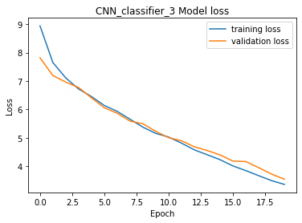

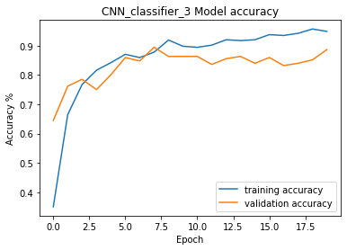

```python
# Plot the training loss, validation loss vs number of epochs and training accuracy, validation accuracy vs number of epochs plot and write your observations on the same.
accuracy      = CNN_classifier_3.history['acc']
val_accuracy  = CNN_classifier_3.history['val_acc']
loss     = CNN_classifier_3.history['loss']
val_loss = CNN_classifier_3.history['val_loss']

epochs   = range(len(accuracy)) # Get number of epochs

plt.xlabel('Epoch')
plt.ylabel('Loss')
plt.plot( epochs, loss, label = 'training loss' )
plt.plot( epochs, val_loss, label = 'validation loss' )
plt.legend(loc = 'upper right')
plt.title ('CNN_classifier_3 Model loss'   )
plt.figure();

plt.xlabel('Epoch')
plt.ylabel('Accuracy %')
plt.plot( epochs, accuracy, label = 'training accuracy' )
plt.plot( epochs, val_accuracy, label = 'validation accuracy' )
plt.title('CNN_classifier_3 Model accuracy')
plt.legend(loc = 'lower right')
plt.figure();
```

#### Observations:

1) The CNN model trained on top of a Transfer Learning model(VGG-16) outperforms all the other models. It has a test accuracy of 88.97% compared to hyper-tuned CNN model with additional Convolutional layers(72.05%), basic CNN model test accuracy(50.36%) and the Supervised Learning model(SVM-rbf classifier - 41.32%).

2) Here we chose VGG-16 over ResNet 50 or MobileNet, since VGG-16 provides a high accuracy on smaller datasets and the training is also less intensive when compared to ResNet50.

2) The train and test loss for the model is quite high, with more epochs and parameter tuning, we should be able to reduce it.

3) Overall, looking at the accuracy, the model performs quite well on both train and test data.

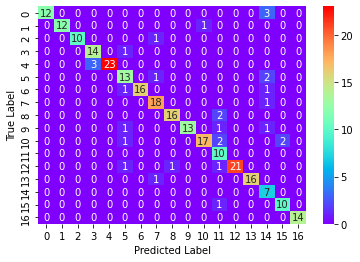

```python
# Evaluating the Confusion Matrix for the final model
# make predictions on test data using the trained CNN model
y_pred = model.predict(X_test)
y_pred_classes = np.argmax(y_pred,axis=1)
y_true = np.argmax(y_test,axis=1)

# calculate confusion matrix
confusion_mtx = confusion_matrix(y_true, y_pred_classes)

# plot confusion matrix as heatmap
sns.heatmap(confusion_mtx, annot=True, fmt='d', cmap='rainbow')
plt.xlabel('Predicted Label')
plt.ylabel('True Label')
plt.show()
```

#### Observations:

1) The model has performed really well and has made mostly made correct predictions for most of the classes in the dataset.

2) Classes 4 and 12 have the highest number of correct predictions.

3) We can further train the model to improve the predictions for classes 14, 2, 15.

```python
# E. Predict the class/label of image ‘Prediction.jpg’ using the best performing model and share the predicted label:
#from keras.preprocessing import image
import keras.utils as image

# Load the image
img = image.load_img('/content/drive/MyDrive/Great_Learning_Repos/00/04_GL_Projects/08_Computer_Vision/Prediction.jpg', target_size=(224, 224))

# Preprocess the image
img = image.img_to_array(img)
MM = MinMaxScaler
img = MinMaxScaler.fit_transform(img)
#img = img / 255.0
img = np.expand_dims(img, axis=0)

# Use the best performing model to predict the label of the image
predicted_class = model.predict(img)
predicted_label = np.argmax(predicted_class, axis=1)
print('Predicted label for the test image is:', predicted_label)
```

```
Predicted label for the test image is: [12]
```

```python
# Creating a function to compare the correctly vs misclassified images
# Import necessary libraries
import numpy as np
import matplotlib.pyplot as plt
from sklearn.preprocessing import LabelEncoder
from keras.utils import to_categorical

def plot_correct_misclassified_images(model, x_test, y_test, n):
    # Get the predicted labels for test data
    pred = model.predict(x_test)
    pred_digits = np.argmax(pred, axis=1)

    # Convert test labels to categorical
    y_test_cat = to_categorical(np.argmax(y_test, axis=1))

    # Create label encoder and fit the categorical test labels
    le = LabelEncoder()
    le.fit(np.argmax(y_test_cat, axis=1))

    # Create empty lists for storing correctly and misclassified indices
    correct_indices = []
    misclassified_indices = []

    # Loop through each predicted label and compare with the true label
    for i in range(len(pred_digits)):
        if pred_digits[i] == np.argmax(y_test_cat[i]):
            correct_indices.append(i)
        else:
            misclassified_indices.append(i)

    # Plot n random correctly classified images
    fig, ax = plt.subplots(int(n/2), 2, figsize=(5, 5))
    fig.suptitle("CORRECTLY CLASSIFIED FLOWER IMAGES")
    for i, axi in enumerate(ax.flat):
        while True:
            index = np.random.randint(0, len(correct_indices))
            if index not in correct_indices[:i]:
                break
        axi.imshow(x_test[correct_indices[index]])
        axi.set_title("Predicted: {}\nTrue: {}".format(le.inverse_transform([pred_digits[correct_indices[index]]])[0], le.inverse_transform([np.argmax(y_test_cat[correct_indices[index]])])[0]))
        axi.axis('off')
        if i == n-1:
            break
    plt.tight_layout()

    # Plot n random misclassified images
    fig, ax = plt.subplots(int(n/2), 2, figsize=(5, 5))
    fig.suptitle("MISCLASSIFIED FLOWER IMAGES")
    for i, axi in enumerate(ax.flat):
        while True:
            index = np.random.randint(0, len(misclassified_indices))
            if index not in misclassified_indices[:i]:
                break
        axi.imshow(x_test[misclassified_indices[index]])
        axi.set_title("Predicted: {}\nTrue: {}".format(le.inverse_transform([pred_digits[misclassified_indices[index]]])[0], le.inverse_transform([np.argmax(y_test_cat[misclassified_indices[index]])])[0]))
        axi.axis('off')
        if i == n-1:
            break
    plt.tight_layout()
```

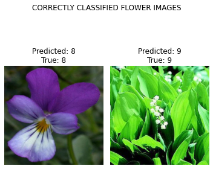

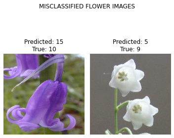

```python
# Call the function
plot_correct_misclassified_images(model, X_test, y_test, 2)
```

## End of Project

```python
# convert colab .ipynb to .html
!jupyter nbconvert --to HTML Computer_Vision_Project.ipynb
```

```
[NbConvertApp] Converting notebook Computer_Vision_Project.ipynb to HTML
[NbConvertApp] Writing 3412248 bytes to Computer_Vision_Project.html
```